# Cosecha de poblaciones

20 de marzo de 2019

## Contenido

- Teoría de la cosecha de poblaciones
- Tarea 01: Solucionario
- Tarea 02: Entrega
- Tarea 03: Instrucciones
- Instalar Git

## Población en equilibrio

> Tamaño de población = Tamaño anterior + Crecimiento

En una población en equilibrio, sin otra fuente de mortalidad más que la cosecha, se puede aplicar esta relación:

\[ H = qEN_t = \mathrm{r_m}N_t\left( 1 - \frac{N_t}{K} \right) \]

- Donde \(H\) es la cosecha.
- \(q\) es el coeficiente de disponibilidad de la población a la cosecha.
- \(E\) es el esfuerzo que se aplica para obtener dicha cosecha.

## Esfuerzo para alcanzar el MRS

Si en la relación anterior sustituimos:

\[ H = \frac{rK}{4} \]

\[ N_t = \frac{K}{2} \]

Entonces podemos determinar el esfuerzo necesario para obtener el Máximo Rendimiento Sostenible:

\[ E_\mathrm{MRS} = \frac{r}{2q} \]

## La cosecha en relación al Esfuerzo

Con esta misma relación, podemos llegar a la cosecha \(H\) en relación al esfuerzo, para un periodo suficientemente largo de tiempo.

\[ H(E) = qEK - \frac{(qE)^2 K}{r} \]

## Ejercicio en clase

Construir la curva con los siguientes parámetros.

```
r <- 0.4
K <- 100
q1 <- 0.002
q2 <- 0.008
```

Superponer la curva con `q2` y distinguirla de `q1`.

## Modelo Bionómico Básico

## Principios

- El crecimiento poblacional sigue una curva de crecimiento logística.
- La cosecha es igual al crecimiento de la población, es decir, que el crecimiento y la cosecha están en equilibrio.
- No hay otros aportes a la población por inmigración, y tampoco hay emigración.
- Esta población también es aprovechada y comerciada por una cantidad significativa de empresas, y tiene una demanda importante; por lo que su precio de venta \(p\) se mantiene estable durante el tiempo.

## Definición 1: El Ingreso Total

El **Ingreso Total** (TR: *Total Revenue*) es igual a la cosecha multiplicada por el precio de venta. Dado que la cosecha está en función del *Esfuerzo*, el Ingreso Total también lo está:

\[ TR(E) = p\times H(E) \]

## Definición 2: Ingreso Promedio Por Unidad de Esfuerzo

El **Ingreso Promedio Por Unidad de Esfuerzo** corresponde al ingreso que se obtiene por cada unidad de esfuerzo aplicada.

\[ AR(E) = \frac{TR(E)}{E} = \frac{p\times H(E)}{E} \]

## Definición 3: Ingreso Marginal

El **Ingreso Marginal** corresponde a la tasa de cambio en el ingreso total (\(TR(E)\)) por cada unidad de esfuerzo añadida.

\[ MR(E) = \frac{dTR(E)}{dE} \]

Si \(MR(E) > 0\) quiere decir que mientras continue el incremento en el esfuerzo, se incrementa el Ingreso Total (\(TR\)). Si \(MR(E) < 0\), por el contrario, incrementar el esfuerzo se traduce en una reducción de \(TR\).

## Definición 4: El Costo Marginal

El **Costo Marginal** corresponde a la tasa de cambio en el costo por cada unidad de esfuerzo añadida. Para este ejemplo asumimos una tasa constante; es decir, cada embarcación añadida a la pesquería incrementa el costo total de la operación por un valor constante \(a\), que llamaremos el costo de operación de la embarcación.

\[ MC(E) = a \]

Si \(dMC(E)/dE > 0\) quiere decir que cada unidad de esfuerzo adicional será más costosa. En nuestro ejemplo, \(da/dE = 0\).

## Definición 5: El costo total

El **Costo Total** corresponde al costo de toda la actividad de cosecha. En este ejemplo, asumimos que el costo total de la operación es igual al Costo Marginal multiplicado por el total de embarcaciones que participan de la pesquería. Este costo por embarcación asume el costo de recursos humanos, materiales, informáticos, legales, etc.

\[ TC(E) = a \times E \]

## El modelo gráficamente

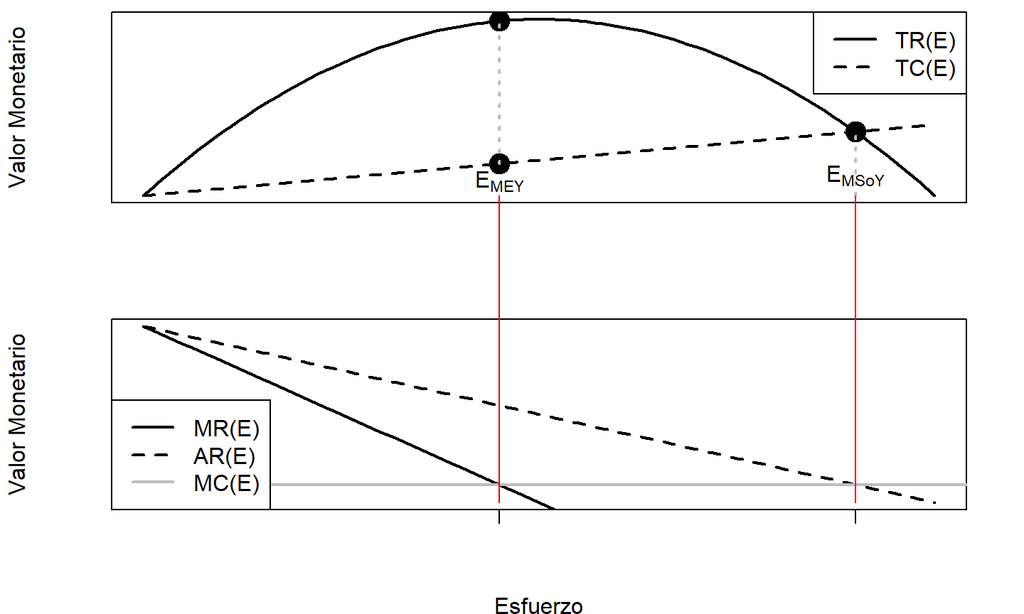

Modelo bionómico básico

## Otros temas

- Tarea 01: Solucionario
- Tarea 02: Entrega
- Tarea 03: Instrucciones
- Instalar Git